# R Notebook

```r
##install.packages("dplyr")
##install.packages("jsonlite")
##install.packages("rjson")
##install.packages("ggplot2")
library(conflicted)
library(rjson)
library(dplyr)
library(jsonlite)
library(tidyverse)
library(ggplot2)
```

# **Proyecto Analisis Descriptivo de canciónes y streming mas exitosos en spotify**

El objetivo principal de este proyecto es analizar mediante los datos por niveles de un JSON y los datos de entrada de un CSV que contienen los id de los streaming y las pistas escuchadas, cual es el stream o la canción mas escuchada y observar la relación entre un rango de duración de las mismas para determinar entre las mejores canciones si hay alguna influencia en la duración de la canción para su éxito para ser tendencia.

## Cargamos el primer dataset

### Primero leemos la data desde el propio JSON

```r
df <- jsonlite::fromJSON('C:/Users/Edgar/Documents/GitHub/DataMining_and_MachineLearning_EdgarV/data/Proyecto1/challenge_set.json')
df
```

```
$date
[1] "2018-01-16 08:47:28.198015"

$version
[1] "v1"

$playlists
```

|  | name | num_holdouts | pid | num_tracks | tracks | num_samples |
| --- | --- | --- | --- | --- | --- | --- |
| 1 | Party | 70 | 1000000 | 75 |  | 5 |
| 2 | school | 73 | 1000016 | 78 |  | 5 |
| 3 | Modern Music | 63 | 1000020 | 68 |  | 5 |
| 4 | lit 2.0 | 49 | 1000023 | 54 |  | 5 |
| 5 | bbq | 71 | 1000040 | 76 |  | 5 |
| 6 | Classic Jams | 60 | 1000049 | 65 |  | 5 |
| 7 | dank | 75 | 1000052 | 80 |  | 5 |
| 8 | Dance | 57 | 1000068 | 62 |  | 5 |
| 9 | Pop Playlist | 49 | 1000082 | 54 |  | 5 |
| 10 | Oldies | 48 | 1000084 | 53 |  | 5 |

[output cut: 990 more lines]

|  | name <chr> | num_holdouts <int> | pid <int> | num_tracks <int> | tracks <list> | num_samples <int> |
| --- | --- | --- | --- | --- | --- | --- |
| 1 | Party | 70 | 1000000 | 75 | <data.frame [5 × 8]> | 5 |
| 2 | school | 73 | 1000016 | 78 | <data.frame [5 × 8]> | 5 |
| 3 | Modern Music | 63 | 1000020 | 68 | <data.frame [5 × 8]> | 5 |
| 4 | lit 2.0 | 49 | 1000023 | 54 | <data.frame [5 × 8]> | 5 |
| 5 | bbq | 71 | 1000040 | 76 | <data.frame [5 × 8]> | 5 |
| 6 | Classic Jams | 60 | 1000049 | 65 | <data.frame [5 × 8]> | 5 |
| 7 | dank | 75 | 1000052 | 80 | <data.frame [5 × 8]> | 5 |
| 8 | Dance | 57 | 1000068 | 62 | <data.frame [5 × 8]> | 5 |
| 9 | Pop Playlist | 49 | 1000082 | 54 | <data.frame [5 × 8]> | 5 |
| 10 | Oldies | 48 | 1000084 | 53 | <data.frame [5 × 8]> | 5 |

1-10 of 9,000 rows

```
$name
[1] "build/challenge/challenge_set.json"

$description
[1] "the challenge set for the RecSys Challenge 2018"
```

### Pasamos a un data frame los datos mas relevantes para nosotros que sería la Playlist

```r
df_spotify <- df$playlists
df_spotify <- df_spotify%>%
  mutate(indice = row.names(.))
df_spotify
```

|  | name | num_holdouts | pid | num_tracks | tracks | num_samples | indice |
| --- | --- | --- | --- | --- | --- | --- | --- |
| 1 | Party | 70 | 1000000 | 75 |  | 5 | 1 |
| 2 | school | 73 | 1000016 | 78 |  | 5 | 2 |
| 3 | Modern Music | 63 | 1000020 | 68 |  | 5 | 3 |
| 4 | lit 2.0 | 49 | 1000023 | 54 |  | 5 | 4 |
| 5 | bbq | 71 | 1000040 | 76 |  | 5 | 5 |
| 6 | Classic Jams | 60 | 1000049 | 65 |  | 5 | 6 |
| 7 | dank | 75 | 1000052 | 80 |  | 5 | 7 |
| 8 | Dance | 57 | 1000068 | 62 |  | 5 | 8 |
| 9 | Pop Playlist | 49 | 1000082 | 54 |  | 5 | 9 |
| 10 | Oldies | 48 | 1000084 | 53 |  | 5 | 10 |

[output cut: 990 more lines]

|  | name <chr> | num_holdouts <int> | pid <int> | num_tracks <int> | tracks <list> | num_samples <int> | indice <chr> |
| --- | --- | --- | --- | --- | --- | --- | --- |
| 1 | Party | 70 | 1000000 | 75 | <data.frame [5 × 8]> | 5 | 1 |
| 2 | school | 73 | 1000016 | 78 | <data.frame [5 × 8]> | 5 | 2 |
| 3 | Modern Music | 63 | 1000020 | 68 | <data.frame [5 × 8]> | 5 | 3 |
| 4 | lit 2.0 | 49 | 1000023 | 54 | <data.frame [5 × 8]> | 5 | 4 |
| 5 | bbq | 71 | 1000040 | 76 | <data.frame [5 × 8]> | 5 | 5 |
| 6 | Classic Jams | 60 | 1000049 | 65 | <data.frame [5 × 8]> | 5 | 6 |
| 7 | dank | 75 | 1000052 | 80 | <data.frame [5 × 8]> | 5 | 7 |
| 8 | Dance | 57 | 1000068 | 62 | <data.frame [5 × 8]> | 5 | 8 |
| 9 | Pop Playlist | 49 | 1000082 | 54 | <data.frame [5 × 8]> | 5 | 9 |
| 10 | Oldies | 48 | 1000084 | 53 | <data.frame [5 × 8]> | 5 | 10 |

1-10 of 9,000 rows

### Exploramos los datos

```r
df_tracks <- df_spotify$tracks
head(df_tracks)
```

|  | pos | artist_name | track_uri | artist_uri | track_name | album_uri | duration_ms | album_name |
| --- | --- | --- | --- | --- | --- | --- | --- | --- |
| 1 | 0 | AronChupa | spotify:track:66U0ASk1VHZsqIkpMjKX3B | spotify:artist:5vCOdeiQt9LyzdI87kt5Sh | Little Swing | spotify:album:4S5MLjwRSi0NJ5nikflYnZ | 163809 | Little Swing |
| 2 | 1 | AronChupa | spotify:track:5MhsZlmKJG6X5kTHkdwC4B | spotify:artist:5vCOdeiQt9LyzdI87kt5Sh | I'm an Albatraoz | spotify:album:1qHVYbxQ6IS8YRviorKDJI | 166848 | I'm an Albatraoz |
| 3 | 2 | Lorde | spotify:track:0GZoB8h0kqXn7XFm4Sj06k | spotify:artist:163tK9Wjr9P9DmM0AVK7lm | Yellow Flicker Beat - From The Hunger Games: Mockingjay Part 1 | spotify:album:4UEPxQx0cTcYNsE0n32MHV | 232506 | Yellow Flicker Beat |
| 4 | 3 | Lorde | spotify:track:35kahykNu00FPysz3C2euR | spotify:artist:163tK9Wjr9P9DmM0AVK7lm | White Teeth Teens | spotify:album:0rmhjUgoVa17LZuS8xWQ3v | 216600 | Pure Heroine |
| 5 | 4 | Lorde | spotify:track:3G6hD9B2ZHOsgf4WfNu7X1 | spotify:artist:163tK9Wjr9P9DmM0AVK7lm | Team | spotify:album:0rmhjUgoVa17LZuS8xWQ3v | 193058 | Pure Heroine |

|  | pos <int> | artist_name <chr> | track_uri <chr> | artist_uri <chr> |  |
| --- | --- | --- | --- | --- | --- |
| 1 | 0 | AronChupa | spotify:track:66U0ASk1VHZsqIkpMjKX3B | spotify:artist:5vCOdeiQt9LyzdI87kt5Sh |  |
| 2 | 1 | AronChupa | spotify:track:5MhsZlmKJG6X5kTHkdwC4B | spotify:artist:5vCOdeiQt9LyzdI87kt5Sh |  |
| 3 | 2 | Lorde | spotify:track:0GZoB8h0kqXn7XFm4Sj06k | spotify:artist:163tK9Wjr9P9DmM0AVK7lm |  |
| 4 | 3 | Lorde | spotify:track:35kahykNu00FPysz3C2euR | spotify:artist:163tK9Wjr9P9DmM0AVK7lm |  |
| 5 | 4 | Lorde | spotify:track:3G6hD9B2ZHOsgf4WfNu7X1 | spotify:artist:163tK9Wjr9P9DmM0AVK7lm |  |

5 rows | 1-5 of 8 columns

|  | pos | artist_name | track_uri | artist_uri | track_name | album_uri | duration_ms | album_name |
| --- | --- | --- | --- | --- | --- | --- | --- | --- |
| 1 | 0 | Alesso | spotify:track:6WQLkih8nE0JdUCEyLaGnQ | spotify:artist:4AVFqumd2ogHFlRbKIjp1t | Heroes (we could be) | spotify:album:3yqh9ozOA2cAgPUJaveAuG | 210012 | Forever |
| 2 | 1 | The Script | spotify:track:37sINbJZcFdHFAsVNsPq1i | spotify:artist:3AQRLZ9PuTAozP28Skbq8V | Superheroes | spotify:album:6yd9yk8nFcHalXzy7mgaDx | 245466 | No Sound Without Silence |
| 3 | 2 | Fall Out Boy | spotify:track:0yhPEz5KxlDwckGJaMlZqM | spotify:artist:4UXqAaa6dQYAk18Lv7PEgX | Centuries | spotify:album:0dAvbhVYW3bGnLldQ8Nvwn | 228360 | American Beauty/American Psycho |
| 4 | 3 | American Authors | spotify:track:5j9iuo3tMmQIfnEEQOOjxh | spotify:artist:0MlOPi3zIDMVrfA9R04Fe3 | Best Day Of My Life | spotify:album:2AAVQqcejMEgNpdg2raPYE | 194240 | Oh, What A Life |
| 5 | 4 | Imagine Dragons | spotify:track:4eLSCSELtKxZwXnFbNLXT5 | spotify:artist:53XhwfbYqKCa1cC15pYq2q | On Top Of The World | spotify:album:1vAEF8F0HoRFGiYOEeJXHW | 189840 | Night Visions |

|  | pos <int> | artist_name <chr> | track_uri <chr> | artist_uri <chr> |  |
| --- | --- | --- | --- | --- | --- |
| 1 | 0 | Alesso | spotify:track:6WQLkih8nE0JdUCEyLaGnQ | spotify:artist:4AVFqumd2ogHFlRbKIjp1t |  |
| 2 | 1 | The Script | spotify:track:37sINbJZcFdHFAsVNsPq1i | spotify:artist:3AQRLZ9PuTAozP28Skbq8V |  |
| 3 | 2 | Fall Out Boy | spotify:track:0yhPEz5KxlDwckGJaMlZqM | spotify:artist:4UXqAaa6dQYAk18Lv7PEgX |  |
| 4 | 3 | American Authors | spotify:track:5j9iuo3tMmQIfnEEQOOjxh | spotify:artist:0MlOPi3zIDMVrfA9R04Fe3 |  |
| 5 | 4 | Imagine Dragons | spotify:track:4eLSCSELtKxZwXnFbNLXT5 | spotify:artist:53XhwfbYqKCa1cC15pYq2q |  |

5 rows | 1-5 of 8 columns

|  | pos | artist_name | track_uri | artist_uri | track_name | album_uri | duration_ms | album_name |
| --- | --- | --- | --- | --- | --- | --- | --- | --- |
| 1 | 0 | Banks | spotify:track:4PvD06Pmbm2rHG2JjSlElF | spotify:artist:2xe8IXgCTpwHE3eA9hTs4n | Beggin For Thread | spotify:album:1eeYYgK208xvkCEGkYqWah | 249739 | Goddess |
| 2 | 1 | Grouplove | spotify:track:57nNNkgk768QVXq3uHxu5e | spotify:artist:3kVUvbeRdcrqQ3oHk5hPdx | Ways To Go | spotify:album:1VNBZDM7OxEQPFbEtVqUuf | 215520 | Spreading Rumours |
| 3 | 2 | Big Data | spotify:track:3y8AEUef1AVfr0npU5UOa9 | spotify:artist:4S1nvNHWiZLP4rzwmULmUa | Dangerous (feat. Joywave) | spotify:album:7MvpqHRTRxHu7QoPiYnmzH | 280426 | 2.0 |
| 4 | 3 | Modest Mouse | spotify:track:5jJ69cMDMC0aeWPjZo6VP2 | spotify:artist:1yAwtBaoHLEDWAnWR87hBT | Lampshades on Fire | spotify:album:6iKqPv9C5oU29LR82N8lJf | 187720 | Strangers to Ourselves |
| 5 | 4 | Marina and the Diamonds | spotify:track:02b5L9jExmkRTdUTqXFzmR | spotify:artist:6CwfuxIqcltXDGjfZsMd9A | Primadonna | spotify:album:1cb2YQ7Ii622olGiImJz2B | 221075 | Electra Heart |

|  | pos <int> | artist_name <chr> | track_uri <chr> |  |
| --- | --- | --- | --- | --- |
| 1 | 0 | Banks | spotify:track:4PvD06Pmbm2rHG2JjSlElF |  |
| 2 | 1 | Grouplove | spotify:track:57nNNkgk768QVXq3uHxu5e |  |
| 3 | 2 | Big Data | spotify:track:3y8AEUef1AVfr0npU5UOa9 |  |
| 4 | 3 | Modest Mouse | spotify:track:5jJ69cMDMC0aeWPjZo6VP2 |  |
| 5 | 4 | Marina and the Diamonds | spotify:track:02b5L9jExmkRTdUTqXFzmR |  |

5 rows | 1-4 of 8 columns

|  | pos | artist_name | track_uri | artist_uri | track_name | album_uri | duration_ms | album_name |
| --- | --- | --- | --- | --- | --- | --- | --- | --- |
| 1 | 0 | Galantis | spotify:track:6fKEplI9iN0JMHsRGQESaT | spotify:artist:4sTQVOfp9vEMCemLw50sbu | Firebird | spotify:album:4QcXq4vTVN7dFb7bZa9jG2 | 248280 | Pharmacy |
| 2 | 1 | Martin Garrix | spotify:track:3ebXMykcMXOcLeJ9xZ17XH | spotify:artist:60d24wfXkVzDSfLS6hyCjZ | Scared to Be Lonely | spotify:album:2v9rQe4F8fVSh5v8bAq0jF | 220883 | Scared to Be Lonely |
| 3 | 2 | Just A Gent | spotify:track:1J9KJgXKFRqKGIzmJ7GjS3 | spotify:artist:1kwGj7uDO5WXVXtQLvGJr0 | Limelight - NGHTMRE Remix | spotify:album:2PfboZYMbgvblTW9a4Lbk9 | 254896 | Limelight |
| 4 | 3 | Carmada | spotify:track:6aBYg6Npa47VAqtEsLsUdz | spotify:artist:4R3mzuQZhfwDkjdE1wx31O | Carmalude | spotify:album:6tLw6pHcjkI7YfjbBWblj6 | 238000 | Realise |
| 5 | 4 | Zedd | spotify:track:0dA2Mk56wEzDgegdC6R17g | spotify:artist:2qxJFvFYMEDqd7ui6kSAcq | Stay (with Alessia Cara) | spotify:album:0VMGOBhLrC5Q2bfZnrocVN | 210090 | Stay |

|  | pos <int> | artist_name <chr> | track_uri <chr> | artist_uri <chr> |  |
| --- | --- | --- | --- | --- | --- |
| 1 | 0 | Galantis | spotify:track:6fKEplI9iN0JMHsRGQESaT | spotify:artist:4sTQVOfp9vEMCemLw50sbu |  |
| 2 | 1 | Martin Garrix | spotify:track:3ebXMykcMXOcLeJ9xZ17XH | spotify:artist:60d24wfXkVzDSfLS6hyCjZ |  |
| 3 | 2 | Just A Gent | spotify:track:1J9KJgXKFRqKGIzmJ7GjS3 | spotify:artist:1kwGj7uDO5WXVXtQLvGJr0 |  |
| 4 | 3 | Carmada | spotify:track:6aBYg6Npa47VAqtEsLsUdz | spotify:artist:4R3mzuQZhfwDkjdE1wx31O |  |
| 5 | 4 | Zedd | spotify:track:0dA2Mk56wEzDgegdC6R17g | spotify:artist:2qxJFvFYMEDqd7ui6kSAcq |  |

5 rows | 1-5 of 8 columns

|  | pos | artist_name | track_uri | artist_uri | track_name | album_uri | duration_ms | album_name |
| --- | --- | --- | --- | --- | --- | --- | --- | --- |
| 1 | 0 | Stick Figure | spotify:track:3ik1fFvzdgmVuiob8t8NlG | spotify:artist:5SXEylV07TC57eanSxxg4R | All My Love | spotify:album:28S63tpbApp3AhWZZYN6l9 | 254680 | Set in Stone |
| 2 | 1 | Stick Figure | spotify:track:05BJQUM4bATKGFheqrC6CW | spotify:artist:5SXEylV07TC57eanSxxg4R | Coming Home | spotify:album:1bAQmWedFHr9gkf7iBlqAE | 283793 | Burial Ground |
| 3 | 2 | Stick Figure | spotify:track:0rfGRC3ng0dxu0xZ3f1bWc | spotify:artist:5SXEylV07TC57eanSxxg4R | Smiles on Faces (feat. KBong) | spotify:album:28S63tpbApp3AhWZZYN6l9 | 256133 | Set in Stone |
| 4 | 3 | Stick Figure | spotify:track:1azvKxDb5Vkph2KR7aq1Cx | spotify:artist:5SXEylV07TC57eanSxxg4R | Choice Is Yours (feat. Slightly Stoopid) | spotify:album:28S63tpbApp3AhWZZYN6l9 | 305493 | Set in Stone |
| 5 | 4 | Stick Figure | spotify:track:1Gsv8f8KmowkF5BnfMIGKy | spotify:artist:5SXEylV07TC57eanSxxg4R | Sound of the Sea | spotify:album:28S63tpbApp3AhWZZYN6l9 | 325480 | Set in Stone |

|  | pos <int> | artist_name <chr> | track_uri <chr> | artist_uri <chr> |  |
| --- | --- | --- | --- | --- | --- |
| 1 | 0 | Stick Figure | spotify:track:3ik1fFvzdgmVuiob8t8NlG | spotify:artist:5SXEylV07TC57eanSxxg4R |  |
| 2 | 1 | Stick Figure | spotify:track:05BJQUM4bATKGFheqrC6CW | spotify:artist:5SXEylV07TC57eanSxxg4R |  |
| 3 | 2 | Stick Figure | spotify:track:0rfGRC3ng0dxu0xZ3f1bWc | spotify:artist:5SXEylV07TC57eanSxxg4R |  |
| 4 | 3 | Stick Figure | spotify:track:1azvKxDb5Vkph2KR7aq1Cx | spotify:artist:5SXEylV07TC57eanSxxg4R |  |
| 5 | 4 | Stick Figure | spotify:track:1Gsv8f8KmowkF5BnfMIGKy | spotify:artist:5SXEylV07TC57eanSxxg4R |  |

5 rows | 1-5 of 8 columns

|  | pos | artist_name | track_uri | artist_uri | track_name | album_uri | duration_ms | album_name |
| --- | --- | --- | --- | --- | --- | --- | --- | --- |
| 1 | 0 | Bon Jovi | spotify:track:3KYiA4vq6RPO1dE2XROXd8 | spotify:artist:58lV9VcRSjABbAbfWS6skp | You Give Love A Bad Name | spotify:album:5uU2uM1RGHfzlA12opjqol | 222706 | Slippery When Wet |
| 2 | 1 | The J. Geils Band | spotify:track:252pAlbltOjOcUux4dRtjp | spotify:artist:69Mj3u4FTUrpyeGNSIaU6F | Must Of Got Lost | spotify:album:333AsLVeAYiUcWE5Me1acm | 178240 | Nightmares...And Other Tales From The Vinyl Jungle |
| 3 | 2 | The J. Geils Band | spotify:track:1ynmMEK1fkyiZ6Z6F3ThEt | spotify:artist:69Mj3u4FTUrpyeGNSIaU6F | Centerfold | spotify:album:48joW5905AMbTFLvy8ZWch | 216533 | Freeze Frame |
| 4 | 3 | Bruce Springsteen | spotify:track:7vIyudiO2Tr9hZ2yzfwQmx | spotify:artist:3eqjTLE0HfPfh78zjh6TqT | Waitin' on a Sunny Day - The Song | spotify:album:23vzCh5cDn0LzdGmGWrT1d | 256133 | The Rising |
| 5 | 4 | Elton John | spotify:track:12yHvSYFXI7PGzNecUvIDu | spotify:artist:3PhoLpVuITZKcymswpck5b | Saturday Night’s Alright (For Fighting) - Remastered | spotify:album:5WupqgR68HfuHt3BMJtgun | 295466 | Goodbye Yellow Brick Road |

|  | pos <int> | artist_name <chr> | track_uri <chr> |  |
| --- | --- | --- | --- | --- |
| 1 | 0 | Bon Jovi | spotify:track:3KYiA4vq6RPO1dE2XROXd8 |  |
| 2 | 1 | The J. Geils Band | spotify:track:252pAlbltOjOcUux4dRtjp |  |
| 3 | 2 | The J. Geils Band | spotify:track:1ynmMEK1fkyiZ6Z6F3ThEt |  |
| 4 | 3 | Bruce Springsteen | spotify:track:7vIyudiO2Tr9hZ2yzfwQmx |  |
| 5 | 4 | Elton John | spotify:track:12yHvSYFXI7PGzNecUvIDu |  |

5 rows | 1-4 of 8 columns

```r
## observamos que para cada lista de pistas hay valores asociados a cada pista como nombre de artista, nombre de la pista y duracion
```

### Verificamos si ningun dato tiene elementos NA

```r
any(is.na(df_tracks))
```

```
[1] FALSE
```

### Cargamos el segundo dataset

#### Eliminaremos columnas que no nos sirvan, pero antes debemos analizar el dataset de los numeros de streamings

```r
df_data_spotify <- read.csv("C:/Users/Edgar/Documents/GitHub/DataMining_and_MachineLearning_EdgarV/data/Proyecto1/sample_submission.csv")

## definimos cual será la primera columna

primera_columna <- df_data_spotify$X1048588
##head(primera_columna,10)

## transformamos las filas restantes en listas
listas_filas <- lapply(1:nrow(df_data_spotify),function(i) as.list(t(df_data_spotify[i,-1])))

##listas_filas
df_tracks_uri <- data.frame(tracks_uri = unlist(listas_filas))
head(df_tracks_uri,2)
```

|  | tracks_uri |
| --- | --- |
| 1 | spotify:track:0JP0Rpqnmllnk2QQ5L8h8O |
| 2 | spotify:track:50JK22El2PTIzZBU2liLDI |

|  | tracks_uri <chr> |  |  |  |
| --- | --- | --- | --- | --- |
| 1 | spotify:track:0JP0Rpqnmllnk2QQ5L8h8O |  |  |  |
| 2 | spotify:track:50JK22El2PTIzZBU2liLDI |  |  |  |

2 rows

```r
## este codigo combinaria cada elemento con una lista de elementos que conforman la fila
##########################################################################################
##df_tracks_uri <- data.frame(tracks_uri = listas_filas)

##combinamos las columnas de los pid con las listas
##df_data_spotify_combinado <- data.frame(pid = primera_columna,tracks_uri = listas_filas)
##head(df_data_spotify_combinado,2)
##head(df_data_spotify_combinado$tracks_uri,1)
##head(df_data_spotify_combinado$tracks_uri,2)
##df_data_spotify_combinado <- as.data.frame(do.call(rbind, listas_combinadas))
##head(df_data_spotify_combinado)
###########################################################################################

##tipo_de_dato <- sapply(df_data_spotify, class)
##df_data_spotify_unificada <- split(df_data_spotify,tipo_de_dato)
```

### Exploramos datos por última vez antes de ir a lo nuestro

#### datos pid

```r
primera_columna <- df_data_spotify$X1048588
df_pid <- data.frame(pid = primera_columna)
head(df_pid,10)
```

|  | pid |
| --- | --- |
| 1 | 1015821 |
| 2 | 1015827 |
| 3 | 1048602 |
| 4 | 1015835 |
| 5 | 1048611 |
| 6 | 1048632 |
| 7 | 1015869 |
| 8 | 1004896 |
| 9 | 1048644 |
| 10 | 1015891 |

|  | pid <int> |  |  |  |
| --- | --- | --- | --- | --- |
| 1 | 1015821 |  |  |  |
| 2 | 1015827 |  |  |  |
| 3 | 1048602 |  |  |  |
| 4 | 1015835 |  |  |  |
| 5 | 1048611 |  |  |  |
| 6 | 1048632 |  |  |  |
| 7 | 1015869 |  |  |  |
| 8 | 1004896 |  |  |  |
| 9 | 1048644 |  |  |  |
| 10 | 1015891 |  |  |  |

1-10 of 10 rows

#### Datos tracks_uri

```r
df_data_spotify <- read.csv("C:/Users/Edgar/Documents/GitHub/DataMining_and_MachineLearning_EdgarV/data/Proyecto1/sample_submission.csv")

## transformamos las filas restantes en listas
listas_filas <- lapply(1:nrow(df_data_spotify),function(i) as.list(t(df_data_spotify[i,-1])))

##dataframe de listas_filas
df_tracks_uri <- data.frame(track_uri = unlist(listas_filas))
head(df_tracks_uri,2)
```

|  | track_uri |
| --- | --- |
| 1 | spotify:track:0JP0Rpqnmllnk2QQ5L8h8O |
| 2 | spotify:track:50JK22El2PTIzZBU2liLDI |

|  | track_uri <chr> |  |  |  |
| --- | --- | --- | --- | --- |
| 1 | spotify:track:0JP0Rpqnmllnk2QQ5L8h8O |  |  |  |
| 2 | spotify:track:50JK22El2PTIzZBU2liLDI |  |  |  |

2 rows

#### Datos track_uri

```r
head(df_tracks_uri,1000)
```

|  | track_uri |
| --- | --- |
| 1 | spotify:track:0JP0Rpqnmllnk2QQ5L8h8O |
| 2 | spotify:track:50JK22El2PTIzZBU2liLDI |
| 3 | spotify:track:5XygCH2SRe55dPC3oRkcTa |
| 4 | spotify:track:6PSedIdcUg5gqSbPhGPOjd |
| 5 | spotify:track:11cQXRVOpqmr71h86RnzKJ |
| 6 | spotify:track:1u1YU1LE0FWHFOHpR2iXua |
| 7 | spotify:track:4lcXNTm9JrQpJYXqsENmFI |
| 8 | spotify:track:5c5a2Ptu8eyIpljhQHjIqk |
| 9 | spotify:track:6ETZTTzlW8VzJ4YBN8i9A8 |
| 10 | spotify:track:6ZbADIIv6JDRQb7ZzAyYP8 |

[output cut: 990 more lines]

|  | track_uri <chr> |  |  |  |
| --- | --- | --- | --- | --- |
| 1 | spotify:track:0JP0Rpqnmllnk2QQ5L8h8O |  |  |  |
| 2 | spotify:track:50JK22El2PTIzZBU2liLDI |  |  |  |
| 3 | spotify:track:5XygCH2SRe55dPC3oRkcTa |  |  |  |
| 4 | spotify:track:6PSedIdcUg5gqSbPhGPOjd |  |  |  |
| 5 | spotify:track:11cQXRVOpqmr71h86RnzKJ |  |  |  |
| 6 | spotify:track:1u1YU1LE0FWHFOHpR2iXua |  |  |  |
| 7 | spotify:track:4lcXNTm9JrQpJYXqsENmFI |  |  |  |
| 8 | spotify:track:5c5a2Ptu8eyIpljhQHjIqk |  |  |  |
| 9 | spotify:track:6ETZTTzlW8VzJ4YBN8i9A8 |  |  |  |
| 10 | spotify:track:6ZbADIIv6JDRQb7ZzAyYP8 |  |  |  |

1-10 of 1,000 rows

### Una vez obtenidos los valores que necesitamos procedemos a contarlos

### Primero empezaremos con los datos pid que nos da la información de cuantos streamings hubo en el proceso de recolección de datos

```r
df_numero_streamings <- df_pid%>%
  select(pid)%>%
  count()
df_numero_streamings
```

| n |
| --- |
| 9999 |

| n <int> |  |  |  |  |
| --- | --- | --- | --- | --- |
| 9999 |  |  |  |  |

1 row

```r
print("ojo que hay que descontar 1000 datos que estaban vacios al realizar la limpieza de los datos ")
```

```
[1] "ojo que hay que descontar 1000 datos que estaban vacios al realizar la limpieza de los datos "
```

### Revisamos si hay datos duplicados

```r
df_numero_streamings_duplicados <- df_pid%>%
  dplyr::filter(duplicated(pid))%>%
  count()
df_numero_streamings_duplicados
```

| n |
| --- |
| 0 |

| n <int> |  |  |  |  |
| --- | --- | --- | --- | --- |
| 0 |  |  |  |  |

1 row

### Ahora verificamos si hay datos repetidos en la columna de tracks_uri que nos muestra la información de la pista

```r
df_numero_tracks_repetidos <- df_tracks_uri%>%
  dplyr::filter(duplicated(track_uri))%>%
  count()
df_numero_tracks_repetidos
```

| n |
| --- |
| 4933257 |

| n <int> |  |  |  |  |
| --- | --- | --- | --- | --- |
| 4933257 |  |  |  |  |

1 row

### Contamos los datos totales de las pistas

```r
df_numero_total_tracks <- df_tracks_uri%>%
  select(track_uri)%>%
  count()
df_numero_total_tracks
```

| n |
| --- |
| 4999500 |

| n <int> |  |  |  |  |
| --- | --- | --- | --- | --- |
| 4999500 |  |  |  |  |

1 row

### Realizamos la diferencia para contabilizar el numero real de pistas

```r
num_real_pistas <- df_numero_total_tracks - df_numero_tracks_repetidos
num_real_pistas
```

| n |
| --- |
| 66243 |

| n <int> |  |  |  |  |
| --- | --- | --- | --- | --- |
| 66243 |  |  |  |  |

1 row

### Contamos los streamings que tiene el otro dataset

```r
num_streamings <- df_spotify%>%
  select(pid)%>%
  count()
num_streamings
```

| n |
| --- |
| 9000 |

| n <int> |  |  |  |  |
| --- | --- | --- | --- | --- |
| 9000 |  |  |  |  |

1 row

```r
NA
```

### Contamos los datos de las pistas del dataset challenge

#### primero unimos los dataframes en uno solo

```r
new_df_tracks <- bind_rows(df_tracks, .id = "dataframe_id")
new_df_tracks
```

| dataframe_id | pos | artist_name | track_uri | artist_uri | track_name | album_uri | duration_ms | album_name |
| --- | --- | --- | --- | --- | --- | --- | --- | --- |
| 1 | 0 | AronChupa | spotify:track:66U0ASk1VHZsqIkpMjKX3B | spotify:artist:5vCOdeiQt9LyzdI87kt5Sh | Little Swing | spotify:album:4S5MLjwRSi0NJ5nikflYnZ | 163809 | Little Swing |
| 1 | 1 | AronChupa | spotify:track:5MhsZlmKJG6X5kTHkdwC4B | spotify:artist:5vCOdeiQt9LyzdI87kt5Sh | I'm an Albatraoz | spotify:album:1qHVYbxQ6IS8YRviorKDJI | 166848 | I'm an Albatraoz |
| 1 | 2 | Lorde | spotify:track:0GZoB8h0kqXn7XFm4Sj06k | spotify:artist:163tK9Wjr9P9DmM0AVK7lm | Yellow Flicker Beat - From The Hunger Games: Mockingjay Part 1 | spotify:album:4UEPxQx0cTcYNsE0n32MHV | 232506 | Yellow Flicker Beat |
| 1 | 3 | Lorde | spotify:track:35kahykNu00FPysz3C2euR | spotify:artist:163tK9Wjr9P9DmM0AVK7lm | White Teeth Teens | spotify:album:0rmhjUgoVa17LZuS8xWQ3v | 216600 | Pure Heroine |
| 1 | 4 | Lorde | spotify:track:3G6hD9B2ZHOsgf4WfNu7X1 | spotify:artist:163tK9Wjr9P9DmM0AVK7lm | Team | spotify:album:0rmhjUgoVa17LZuS8xWQ3v | 193058 | Pure Heroine |
| 2 | 0 | Alesso | spotify:track:6WQLkih8nE0JdUCEyLaGnQ | spotify:artist:4AVFqumd2ogHFlRbKIjp1t | Heroes (we could be) | spotify:album:3yqh9ozOA2cAgPUJaveAuG | 210012 | Forever |
| 2 | 1 | The Script | spotify:track:37sINbJZcFdHFAsVNsPq1i | spotify:artist:3AQRLZ9PuTAozP28Skbq8V | Superheroes | spotify:album:6yd9yk8nFcHalXzy7mgaDx | 245466 | No Sound Without Silence |
| 2 | 2 | Fall Out Boy | spotify:track:0yhPEz5KxlDwckGJaMlZqM | spotify:artist:4UXqAaa6dQYAk18Lv7PEgX | Centuries | spotify:album:0dAvbhVYW3bGnLldQ8Nvwn | 228360 | American Beauty/American Psycho |
| 2 | 3 | American Authors | spotify:track:5j9iuo3tMmQIfnEEQOOjxh | spotify:artist:0MlOPi3zIDMVrfA9R04Fe3 | Best Day Of My Life | spotify:album:2AAVQqcejMEgNpdg2raPYE | 194240 | Oh, What A Life |
| 2 | 4 | Imagine Dragons | spotify:track:4eLSCSELtKxZwXnFbNLXT5 | spotify:artist:53XhwfbYqKCa1cC15pYq2q | On Top Of The World | spotify:album:1vAEF8F0HoRFGiYOEeJXHW | 189840 | Night Visions |

[output cut: 990 more lines]

| dataframe_id <chr> | pos <int> | artist_name <chr> | track_uri <chr> |  |
| --- | --- | --- | --- | --- |
| 1 | 0 | AronChupa | spotify:track:66U0ASk1VHZsqIkpMjKX3B |  |
| 1 | 1 | AronChupa | spotify:track:5MhsZlmKJG6X5kTHkdwC4B |  |
| 1 | 2 | Lorde | spotify:track:0GZoB8h0kqXn7XFm4Sj06k |  |
| 1 | 3 | Lorde | spotify:track:35kahykNu00FPysz3C2euR |  |
| 1 | 4 | Lorde | spotify:track:3G6hD9B2ZHOsgf4WfNu7X1 |  |
| 2 | 0 | Alesso | spotify:track:6WQLkih8nE0JdUCEyLaGnQ |  |
| 2 | 1 | The Script | spotify:track:37sINbJZcFdHFAsVNsPq1i |  |
| 2 | 2 | Fall Out Boy | spotify:track:0yhPEz5KxlDwckGJaMlZqM |  |
| 2 | 3 | American Authors | spotify:track:5j9iuo3tMmQIfnEEQOOjxh |  |
| 2 | 4 | Imagine Dragons | spotify:track:4eLSCSELtKxZwXnFbNLXT5 |  |

1-10 of 281,000 rows | 1-4 of 9 columns

#### Contamos el numero de pistas que tiene este dataset

```r
num_tracks <- new_df_tracks%>%
  select(track_uri)%>%
  count()
num_tracks
```

| n |
| --- |
| 281000 |

| n <int> |  |  |  |  |
| --- | --- | --- | --- | --- |
| 281000 |  |  |  |  |

1 row

#### Revisamos si no hay repetidos

```r
num_tracks <- new_df_tracks%>%
  distinct(track_uri)%>%
  count()
num_tracks
```

| n |
| --- |
| 66243 |

| n <int> |  |  |  |  |
| --- | --- | --- | --- | --- |
| 66243 |  |  |  |  |

1 row

#### Comparamos con el número real de pistas

```r
comparison <- data.frame(num_tracks_JSON=num_real_pistas, num_tracks_csv= num_tracks )
comparison
```

| n | n.1 |
| --- | --- |
| 66243 | 66243 |

| n <int> | n.1 <int> |  |  |  |
| --- | --- | --- | --- | --- |
| 66243 | 66243 |  |  |  |

1 row

### … Por lo tanto los datos van acorde con este proyecto.

# Objetivo 1.-

## Extraer las características de los streaming de canciones y de sus pistas como su nombre, artista, el número de pistas (en el caso del Streaming) y la duración de la pista.

```r
head(df_spotify,10)
```

|  | name | num_holdouts | pid | num_tracks | tracks | num_samples | indice |
| --- | --- | --- | --- | --- | --- | --- | --- |
| 1 | Party | 70 | 1000000 | 75 |  | 5 | 1 |
| 2 | school | 73 | 1000016 | 78 |  | 5 | 2 |
| 3 | Modern Music | 63 | 1000020 | 68 |  | 5 | 3 |
| 4 | lit 2.0 | 49 | 1000023 | 54 |  | 5 | 4 |
| 5 | bbq | 71 | 1000040 | 76 |  | 5 | 5 |
| 6 | Classic Jams | 60 | 1000049 | 65 |  | 5 | 6 |
| 7 | dank | 75 | 1000052 | 80 |  | 5 | 7 |
| 8 | Dance | 57 | 1000068 | 62 |  | 5 | 8 |
| 9 | Pop Playlist | 49 | 1000082 | 54 |  | 5 | 9 |
| 10 | Oldies | 48 | 1000084 | 53 |  | 5 | 10 |

|  | name <chr> | num_holdouts <int> | pid <int> | num_tracks <int> | tracks <list> | num_samples <int> | indice <chr> |
| --- | --- | --- | --- | --- | --- | --- | --- |
| 1 | Party | 70 | 1000000 | 75 | <data.frame [5 × 8]> | 5 | 1 |
| 2 | school | 73 | 1000016 | 78 | <data.frame [5 × 8]> | 5 | 2 |
| 3 | Modern Music | 63 | 1000020 | 68 | <data.frame [5 × 8]> | 5 | 3 |
| 4 | lit 2.0 | 49 | 1000023 | 54 | <data.frame [5 × 8]> | 5 | 4 |
| 5 | bbq | 71 | 1000040 | 76 | <data.frame [5 × 8]> | 5 | 5 |
| 6 | Classic Jams | 60 | 1000049 | 65 | <data.frame [5 × 8]> | 5 | 6 |
| 7 | dank | 75 | 1000052 | 80 | <data.frame [5 × 8]> | 5 | 7 |
| 8 | Dance | 57 | 1000068 | 62 | <data.frame [5 × 8]> | 5 | 8 |
| 9 | Pop Playlist | 49 | 1000082 | 54 | <data.frame [5 × 8]> | 5 | 9 |
| 10 | Oldies | 48 | 1000084 | 53 | <data.frame [5 × 8]> | 5 | 10 |

1-10 of 10 rows

```r
head(new_df_tracks,10)
```

|  | dataframe_id | pos | artist_name | track_uri | artist_uri | track_name | album_uri | duration_ms | album_name |
| --- | --- | --- | --- | --- | --- | --- | --- | --- | --- |
| 1 | 1 | 0 | AronChupa | spotify:track:66U0ASk1VHZsqIkpMjKX3B | spotify:artist:5vCOdeiQt9LyzdI87kt5Sh | Little Swing | spotify:album:4S5MLjwRSi0NJ5nikflYnZ | 163809 | Little Swing |
| 2 | 1 | 1 | AronChupa | spotify:track:5MhsZlmKJG6X5kTHkdwC4B | spotify:artist:5vCOdeiQt9LyzdI87kt5Sh | I'm an Albatraoz | spotify:album:1qHVYbxQ6IS8YRviorKDJI | 166848 | I'm an Albatraoz |
| 3 | 1 | 2 | Lorde | spotify:track:0GZoB8h0kqXn7XFm4Sj06k | spotify:artist:163tK9Wjr9P9DmM0AVK7lm | Yellow Flicker Beat - From The Hunger Games: Mockingjay Part 1 | spotify:album:4UEPxQx0cTcYNsE0n32MHV | 232506 | Yellow Flicker Beat |
| 4 | 1 | 3 | Lorde | spotify:track:35kahykNu00FPysz3C2euR | spotify:artist:163tK9Wjr9P9DmM0AVK7lm | White Teeth Teens | spotify:album:0rmhjUgoVa17LZuS8xWQ3v | 216600 | Pure Heroine |
| 5 | 1 | 4 | Lorde | spotify:track:3G6hD9B2ZHOsgf4WfNu7X1 | spotify:artist:163tK9Wjr9P9DmM0AVK7lm | Team | spotify:album:0rmhjUgoVa17LZuS8xWQ3v | 193058 | Pure Heroine |
| 6 | 2 | 0 | Alesso | spotify:track:6WQLkih8nE0JdUCEyLaGnQ | spotify:artist:4AVFqumd2ogHFlRbKIjp1t | Heroes (we could be) | spotify:album:3yqh9ozOA2cAgPUJaveAuG | 210012 | Forever |
| 7 | 2 | 1 | The Script | spotify:track:37sINbJZcFdHFAsVNsPq1i | spotify:artist:3AQRLZ9PuTAozP28Skbq8V | Superheroes | spotify:album:6yd9yk8nFcHalXzy7mgaDx | 245466 | No Sound Without Silence |
| 8 | 2 | 2 | Fall Out Boy | spotify:track:0yhPEz5KxlDwckGJaMlZqM | spotify:artist:4UXqAaa6dQYAk18Lv7PEgX | Centuries | spotify:album:0dAvbhVYW3bGnLldQ8Nvwn | 228360 | American Beauty/American Psycho |
| 9 | 2 | 3 | American Authors | spotify:track:5j9iuo3tMmQIfnEEQOOjxh | spotify:artist:0MlOPi3zIDMVrfA9R04Fe3 | Best Day Of My Life | spotify:album:2AAVQqcejMEgNpdg2raPYE | 194240 | Oh, What A Life |
| 10 | 2 | 4 | Imagine Dragons | spotify:track:4eLSCSELtKxZwXnFbNLXT5 | spotify:artist:53XhwfbYqKCa1cC15pYq2q | On Top Of The World | spotify:album:1vAEF8F0HoRFGiYOEeJXHW | 189840 | Night Visions |

|  | dataframe_id <chr> | pos <int> | artist_name <chr> | track_uri <chr> |  |
| --- | --- | --- | --- | --- | --- |
| 1 | 1 | 0 | AronChupa | spotify:track:66U0ASk1VHZsqIkpMjKX3B |  |
| 2 | 1 | 1 | AronChupa | spotify:track:5MhsZlmKJG6X5kTHkdwC4B |  |
| 3 | 1 | 2 | Lorde | spotify:track:0GZoB8h0kqXn7XFm4Sj06k |  |
| 4 | 1 | 3 | Lorde | spotify:track:35kahykNu00FPysz3C2euR |  |
| 5 | 1 | 4 | Lorde | spotify:track:3G6hD9B2ZHOsgf4WfNu7X1 |  |
| 6 | 2 | 0 | Alesso | spotify:track:6WQLkih8nE0JdUCEyLaGnQ |  |
| 7 | 2 | 1 | The Script | spotify:track:37sINbJZcFdHFAsVNsPq1i |  |
| 8 | 2 | 2 | Fall Out Boy | spotify:track:0yhPEz5KxlDwckGJaMlZqM |  |
| 9 | 2 | 3 | American Authors | spotify:track:5j9iuo3tMmQIfnEEQOOjxh |  |
| 10 | 2 | 4 | Imagine Dragons | spotify:track:4eLSCSELtKxZwXnFbNLXT5 |  |

1-10 of 10 rows | 1-5 of 9 columns

# Objetivo 2.-

## Hallar las pistas mas sonadas y el streamings más escuchados.

```r
pistas_mas_sonadas <- left_join(new_df_tracks, df_tracks_uri, by="track_uri")
conteo <- pistas_mas_sonadas %>% count(track_uri)
pistas_mas_sonadas <- left_join(new_df_tracks, conteo, by="track_uri")
pistas_mas_sonadas <- arrange(pistas_mas_sonadas,desc(n))
pistas_mas_sonadas_top <- distinct(pistas_mas_sonadas,track_uri,.keep_all = TRUE)
colnames(pistas_mas_sonadas_top)[colnames(pistas_mas_sonadas_top) == "n"] <- "popularidad"
pistas_mas_sonadas_top
```

| dataframe_id | pos | artist_name | track_uri | artist_uri | track_name | album_uri | duration_ms | album_name | popularidad |
| --- | --- | --- | --- | --- | --- | --- | --- | --- | --- |
| 140 | 2 | DRAM | spotify:track:7yyRTcZmCiyzzJlNzGC9Ol | spotify:artist:5M0lbkGluOPXLeFjApw8r8 | Broccoli (feat. Lil Yachty) | spotify:album:0NrZHZ0y5kTO8EHliuUUca | 225205 | Big Baby DRAM | 226 |
| 231 | 2 | R. Kelly | spotify:track:5dNfHmqgr128gMY2tc5CeJ | spotify:artist:2mxe0TnaNL039ysAj51xPQ | Ignition - Remix | spotify:album:35Ea7OWXZPZB1vAPiaEGOM | 186066 | Chocolate Factory | 222 |
| 311 | 1 | Kanye West | spotify:track:5XJJdNPkwmbUwE79gv0NxK | spotify:artist:5K4W6rqBFWDnAN6FQUkS6x | Gold Digger | spotify:album:4GRDFQ9HRoO0by8H0r2a3I | 207626 | Late Registration | 215 |
| 139 | 4 | J. Cole | spotify:track:62vpWI1CHwFy7tMIcSStl8 | spotify:artist:6l3HvQ5sa6mXTsMTB19rO5 | No Role Modelz | spotify:album:7viNUmZZ8ztn2UB4XB3jIL | 292986 | 2014 Forest Hills Drive | 211 |
| 68 | 2 | The Chainsmokers | spotify:track:7BKLCZ1jbUBVqRi2FVlTVw | spotify:artist:69GGBxA162lTqCwzJG5jLp | Closer | spotify:album:0rSLgV8p5FzfnqlEk4GzxE | 244960 | Closer | 206 |
| 158 | 1 | Kendrick Lamar | spotify:track:7KXjTSCq5nL1LoYtL7XAwS | spotify:artist:2YZyLoL8N0Wb9xBt1NhZWg | HUMBLE. | spotify:album:4eLPsYPBmXABThSJ821sqY | 177000 | DAMN. | 202 |
| 160 | 1 | Drake | spotify:track:27GmP9AWRs744SzKcpJsTZ | spotify:artist:3TVXtAsR1Inumwj472S9r4 | Jumpman | spotify:album:1ozpmkWcCHwsQ4QTnxOOdT | 205879 | What A Time To Be Alive | 198 |
| 8 | 3 | Drake | spotify:track:1xznGGDReH1oQq0xzbwXa3 | spotify:artist:3TVXtAsR1Inumwj472S9r4 | One Dance | spotify:album:3hARKC8cinq3mZLLAEaBh9 | 173986 | Views | 197 |
| 922 | 2 | Chance The Rapper | spotify:track:0v9Wz8o0BT8DU38R4ddjeH | spotify:artist:1anyVhU62p31KFi8MEzkbf | No Problem (feat. Lil Wayne & 2 Chainz) | spotify:album:71QyofYesSsRMwFOTafnhB | 304606 | Coloring Book | 196 |
| 454 | 2 | Migos | spotify:track:4Km5HrUvYTaSUfiSGPJeQR | spotify:artist:6oMuImdp5ZcFhWP0ESe6mG | Bad and Boujee (feat. Lil Uzi Vert) | spotify:album:2AvupjUeMnSffKEV05x222 | 343150 | Culture | 186 |

[output cut: 990 more lines]

| dataframe_id <chr> | pos <int> | artist_name <chr> | track_uri <chr> |  |
| --- | --- | --- | --- | --- |
| 140 | 2 | DRAM | spotify:track:7yyRTcZmCiyzzJlNzGC9Ol |  |
| 231 | 2 | R. Kelly | spotify:track:5dNfHmqgr128gMY2tc5CeJ |  |
| 311 | 1 | Kanye West | spotify:track:5XJJdNPkwmbUwE79gv0NxK |  |
| 139 | 4 | J. Cole | spotify:track:62vpWI1CHwFy7tMIcSStl8 |  |
| 68 | 2 | The Chainsmokers | spotify:track:7BKLCZ1jbUBVqRi2FVlTVw |  |
| 158 | 1 | Kendrick Lamar | spotify:track:7KXjTSCq5nL1LoYtL7XAwS |  |
| 160 | 1 | Drake | spotify:track:27GmP9AWRs744SzKcpJsTZ |  |
| 8 | 3 | Drake | spotify:track:1xznGGDReH1oQq0xzbwXa3 |  |
| 922 | 2 | Chance The Rapper | spotify:track:0v9Wz8o0BT8DU38R4ddjeH |  |
| 454 | 2 | Migos | spotify:track:4Km5HrUvYTaSUfiSGPJeQR |  |

1-10 of 66,243 rows | 1-4 of 10 columns

#### Guardamos en un dataframe los 1000 mas escuchados y desplegaremos los 10 mas escuchados

```r
top_1000 <- head(pistas_mas_sonadas_top,1000)
top_10 <- head(pistas_mas_sonadas_top,10)
top_10
```

|  | dataframe_id | pos | artist_name | track_uri | artist_uri | track_name | album_uri | duration_ms | album_name | popularidad |
| --- | --- | --- | --- | --- | --- | --- | --- | --- | --- | --- |
| 1 | 140 | 2 | DRAM | spotify:track:7yyRTcZmCiyzzJlNzGC9Ol | spotify:artist:5M0lbkGluOPXLeFjApw8r8 | Broccoli (feat. Lil Yachty) | spotify:album:0NrZHZ0y5kTO8EHliuUUca | 225205 | Big Baby DRAM | 226 |
| 2 | 231 | 2 | R. Kelly | spotify:track:5dNfHmqgr128gMY2tc5CeJ | spotify:artist:2mxe0TnaNL039ysAj51xPQ | Ignition - Remix | spotify:album:35Ea7OWXZPZB1vAPiaEGOM | 186066 | Chocolate Factory | 222 |
| 3 | 311 | 1 | Kanye West | spotify:track:5XJJdNPkwmbUwE79gv0NxK | spotify:artist:5K4W6rqBFWDnAN6FQUkS6x | Gold Digger | spotify:album:4GRDFQ9HRoO0by8H0r2a3I | 207626 | Late Registration | 215 |
| 4 | 139 | 4 | J. Cole | spotify:track:62vpWI1CHwFy7tMIcSStl8 | spotify:artist:6l3HvQ5sa6mXTsMTB19rO5 | No Role Modelz | spotify:album:7viNUmZZ8ztn2UB4XB3jIL | 292986 | 2014 Forest Hills Drive | 211 |
| 5 | 68 | 2 | The Chainsmokers | spotify:track:7BKLCZ1jbUBVqRi2FVlTVw | spotify:artist:69GGBxA162lTqCwzJG5jLp | Closer | spotify:album:0rSLgV8p5FzfnqlEk4GzxE | 244960 | Closer | 206 |
| 6 | 158 | 1 | Kendrick Lamar | spotify:track:7KXjTSCq5nL1LoYtL7XAwS | spotify:artist:2YZyLoL8N0Wb9xBt1NhZWg | HUMBLE. | spotify:album:4eLPsYPBmXABThSJ821sqY | 177000 | DAMN. | 202 |
| 7 | 160 | 1 | Drake | spotify:track:27GmP9AWRs744SzKcpJsTZ | spotify:artist:3TVXtAsR1Inumwj472S9r4 | Jumpman | spotify:album:1ozpmkWcCHwsQ4QTnxOOdT | 205879 | What A Time To Be Alive | 198 |
| 8 | 8 | 3 | Drake | spotify:track:1xznGGDReH1oQq0xzbwXa3 | spotify:artist:3TVXtAsR1Inumwj472S9r4 | One Dance | spotify:album:3hARKC8cinq3mZLLAEaBh9 | 173986 | Views | 197 |
| 9 | 922 | 2 | Chance The Rapper | spotify:track:0v9Wz8o0BT8DU38R4ddjeH | spotify:artist:1anyVhU62p31KFi8MEzkbf | No Problem (feat. Lil Wayne & 2 Chainz) | spotify:album:71QyofYesSsRMwFOTafnhB | 304606 | Coloring Book | 196 |
| 10 | 454 | 2 | Migos | spotify:track:4Km5HrUvYTaSUfiSGPJeQR | spotify:artist:6oMuImdp5ZcFhWP0ESe6mG | Bad and Boujee (feat. Lil Uzi Vert) | spotify:album:2AvupjUeMnSffKEV05x222 | 343150 | Culture | 186 |

|  | dataframe_id <chr> | pos <int> | artist_name <chr> | track_uri <chr> |  |
| --- | --- | --- | --- | --- | --- |
| 1 | 140 | 2 | DRAM | spotify:track:7yyRTcZmCiyzzJlNzGC9Ol |  |
| 2 | 231 | 2 | R. Kelly | spotify:track:5dNfHmqgr128gMY2tc5CeJ |  |
| 3 | 311 | 1 | Kanye West | spotify:track:5XJJdNPkwmbUwE79gv0NxK |  |
| 4 | 139 | 4 | J. Cole | spotify:track:62vpWI1CHwFy7tMIcSStl8 |  |
| 5 | 68 | 2 | The Chainsmokers | spotify:track:7BKLCZ1jbUBVqRi2FVlTVw |  |
| 6 | 158 | 1 | Kendrick Lamar | spotify:track:7KXjTSCq5nL1LoYtL7XAwS |  |
| 7 | 160 | 1 | Drake | spotify:track:27GmP9AWRs744SzKcpJsTZ |  |
| 8 | 8 | 3 | Drake | spotify:track:1xznGGDReH1oQq0xzbwXa3 |  |
| 9 | 922 | 2 | Chance The Rapper | spotify:track:0v9Wz8o0BT8DU38R4ddjeH |  |
| 10 | 454 | 2 | Migos | spotify:track:4Km5HrUvYTaSUfiSGPJeQR |  |

1-10 of 10 rows | 1-5 of 10 columns

#### Realizamos el grafico de audiencia del top 10

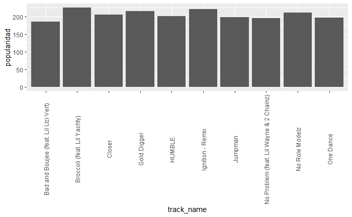

```r
grafico <- ggplot(top_10, aes(x = track_name, y = popularidad)) +
  geom_bar(stat = "identity") + theme(axis.text.x = element_text(angle = 90, vjust = 0.5))
grafico
```

#### Vemos cual es el mejor streaming

```r
mejor_streaming <- df_spotify%>%
  dplyr::filter(indice == top_10$dataframe_id)
mejor_streaming
```

| name | num_holdouts | pid | num_tracks | tracks | num_samples | indice |
| --- | --- | --- | --- | --- | --- | --- |
| Dance | 57 | 1000068 | 62 |  | 5 | 8 |

| name <chr> | num_holdouts <int> | pid <int> | num_tracks <int> | tracks <list> | num_samples <int> | indice <chr> |
| --- | --- | --- | --- | --- | --- | --- |
| Dance | 57 | 1000068 | 62 | <data.frame [5 × 8]> | 5 | 8 |

1 row

```r
lista_pistas <- new_df_tracks%>%
  dplyr::filter(dataframe_id == 8)
lista_pistas
```

| dataframe_id | pos | artist_name | track_uri | artist_uri | track_name | album_uri | duration_ms | album_name |
| --- | --- | --- | --- | --- | --- | --- | --- | --- |
| 8 | 0 | Fetty Wap | spotify:track:6BOtDFg6GJm0rPUDuNmx57 | spotify:artist:6PXS4YHDkKvl1wkIl4V8DL | Wake Up | spotify:album:7vhZcSEXGx8dHt1O5coI7Z | 224000 | Wake Up |
| 8 | 1 | Drake | spotify:track:6F609ICg9Spjrw1epsAnpa | spotify:artist:3TVXtAsR1Inumwj472S9r4 | Controlla | spotify:album:3hARKC8cinq3mZLLAEaBh9 | 245226 | Views |
| 8 | 2 | Rihanna | spotify:track:14WWzenpaEgQZlqPq2nk4v | spotify:artist:5pKCCKE2ajJHZ9KAiaK11H | Work | spotify:album:2JNVoEx4psIgNQyEExwQVn | 219320 | ANTI |
| 8 | 3 | Drake | spotify:track:1xznGGDReH1oQq0xzbwXa3 | spotify:artist:3TVXtAsR1Inumwj472S9r4 | One Dance | spotify:album:3hARKC8cinq3mZLLAEaBh9 | 173986 | Views |
| 8 | 4 | Gnarls Barkley | spotify:track:1vxw6aYJls2oq3gW0DujAo | spotify:artist:5SbkVQYYzlw1kte75QIabH | Crazy | spotify:album:5I0Wf7lRLZArM1K2uQ1AEA | 177466 | St. Elsewhere |

| dataframe_id <chr> | pos <int> | artist_name <chr> | track_uri <chr> |  |
| --- | --- | --- | --- | --- |
| 8 | 0 | Fetty Wap | spotify:track:6BOtDFg6GJm0rPUDuNmx57 |  |
| 8 | 1 | Drake | spotify:track:6F609ICg9Spjrw1epsAnpa |  |
| 8 | 2 | Rihanna | spotify:track:14WWzenpaEgQZlqPq2nk4v |  |
| 8 | 3 | Drake | spotify:track:1xznGGDReH1oQq0xzbwXa3 |  |
| 8 | 4 | Gnarls Barkley | spotify:track:1vxw6aYJls2oq3gW0DujAo |  |

5 rows | 1-4 of 9 columns

#### El Artista mas escuchado debido a su numero de canciones mas escuchadas

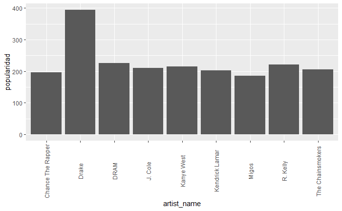

```r
ggplot(top_10, aes(x = artist_name, y = popularidad)) +
  geom_bar(stat = "identity") + theme(axis.text.x = element_text(angle = 90, vjust = 0.5))
```

#### El Album mas escuchado debido a su numero de canciones mas escuchadas dentro de este

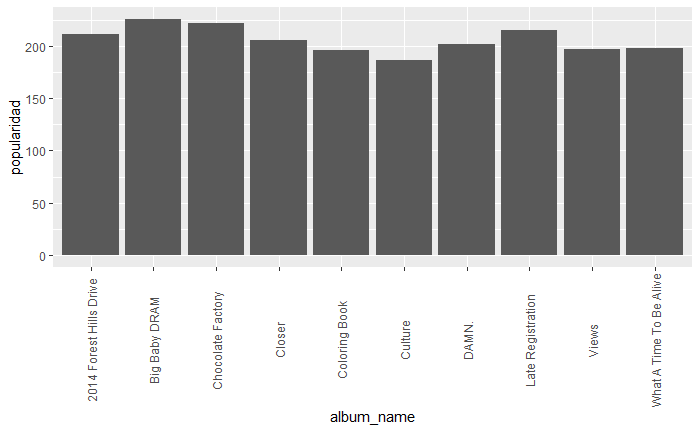

```r
ggplot(top_10, aes(x = album_name, y = popularidad)) +
  geom_bar(stat = "identity") + theme(axis.text.x = element_text(angle = 90, vjust = 0.5))
```

# Objetivo 3.-

### Relacionar las características de cada canción con los resultados para determinar que tienen en común.

#### Realizamos un gráfico de burbujas para relacionar la popularidad vs un album y su artista

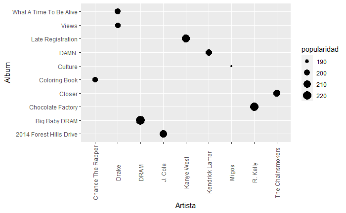

```r
ggplot(top_10, aes(x = artist_name , y = album_name, size = popularidad)) +
  geom_point() +
  xlab("Artista") +
  ylab("Album") +
  scale_size_continuous(name = "popularidad") + theme(axis.text.x = element_text(angle = 90, vjust = 0.5))
```

#### Realizamos un gráfico de burbujas para relacionar la popularidad vs un album y sus canciones

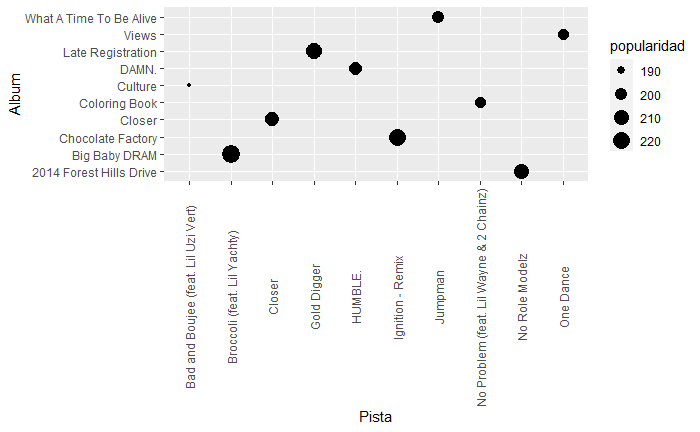

```r
ggplot(top_10, aes(x = track_name , y = album_name, size = popularidad)) +
  geom_point() +
  xlab("Pista") +
  ylab("Album") +
  scale_size_continuous(name = "popularidad") + theme(axis.text.x = element_text(angle = 90, vjust = 0.5))
```

#### Jugaremos con el top 1000 de canciones, haciendo un grafico de dispersión respecto al tiempo de duración de la canción con el top

```r
mediana_duración <- median(top_1000$duration_ms)
mediana_duración/60000
```

```
[1] 3.757775
```

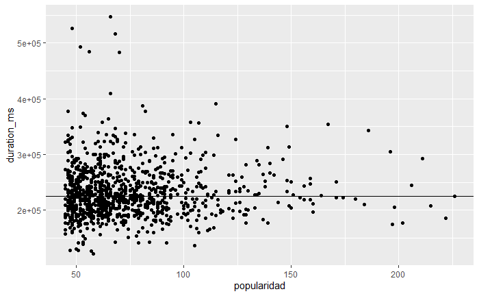

```r
relación_dpopularidad_duración_pista <- ggplot(top_1000, aes(x = popularidad, y = duration_ms)) +
  geom_point() + geom_hline(yintercept = mediana_duración)
relación_dpopularidad_duración_pista
```

#### Para mi perspectiva, el enfoque al que quería llegar era diferente, intuyo que debido a que los datos fueron tomados en tiempo mucho antes de la Pandemia del 2019 en la que la cultura cambió bastante, se esperaba que canciones con corta duración sean mas populares que una de larga duración, como referencia a videos de corta duración de Tik Tok.